# Using Python to improve my Fantasy Basketball team

[figure not shown]

## Nikolaos Michas

### PyCon Balkan 2018

# What is Fantasy Basketball ?

# Fantasy sport

From Wikipedia, the free encyclopedia

A **fantasy sport** (also known less commonly as **rotisserie** or **roto**) is a type of online game where participants assemble imaginary or virtual teams of real players of a professional sport. These teams compete based on the statistical performance of those players' players in actual games. This performance is converted into points that are compiled and totaled according to a roster selected by each fantasy team's manager. These point systems can be simple enough to be manually calculated by a "league commissioner" who coordinates and manages the overall league, or points can be compiled and calculated using computers tracking actual results of the professional sport. In fantasy sports, team owners draft, trade and cut (drop) players, analogously to real sports.

## Basic Rules

- Team owner drafts a team of 13 players
- Each week owners select 10 active players
- Owners collect points based on their picks' performance

[figure not shown]

## Each Player collects points from the following statistics

- Field Goals Made (FGM) 1.5
- Field Goals Attempted (FGA)  -0.5
- Free Throws Made (FTM) 1
- Free Throws Attempted (FTA) -0.75
- Three Pointers Made (3PM) 1
- Three Pointers Attempted (3PA) -0.25
- Offensive Rebounds (OREB) 0.5
- Rebounds (REB) 1
- Assists (AST) 2
- Steals (STL) 2.5
- Blocks (BLK) 2.5
- Turnovers (TO) -1.75
- Points (PTS) 1

# How to improve my team?

- Improve Draft Process
- Make smarter moves during the season (based on schedule and form)

### Use Python

- Pandas
- Beautiful Soup
- Jupyter
- Seaborn / Plotly
- Scikit Learn
- Keras

## Step 0.

## Pandas

https://pandas.pydata.org/pandas-docs/stable/

**pandas** is a Python package providing fast, flexible, and expressive data structures designed to make working with “relational” or “labeled” data both easy and intuitive. It aims to be the fundamental high-level building block for doing practical, **real world** data analysis in Python. Additionally, it has the broader goal of becoming **the most powerful and flexible open source data analysis / manipulation tool available in any language**. It is already well on its way toward this goal.

```
(venv) [nmichas@my-pc]$ pip install pandas
```

# pandas.DataFrame

Two-dimensional size-mutable, potentially heterogeneous tabular data structure with labeled axes (rows and columns). Arithmetic operations align on both row and column labels. Can be thought of as a dict-like container for Series objects. The primary pandas data structure.

```python
import pandas as pd
import numpy as np
df = pd.DataFrame(np.random.randn(6,4), columns=list('ABCD'))
```

```python
df
```

|  | A | B | C | D |
| --- | --- | --- | --- | --- |
| 0 | -2.629103 | 0.499507 | -0.212728 | 1.577970 |
| 1 | -0.609528 | -0.812423 | 0.272661 | 1.971352 |
| 2 | -0.967961 | 0.375162 | -0.699963 | 0.761627 |
| 3 | 0.930821 | 1.601370 | 0.801817 | -0.822172 |
| 4 | 1.292109 | 1.787799 | 1.297442 | 0.494045 |
| 5 | -0.238296 | -1.198859 | -0.633655 | 0.145658 |

## Step 1.

### Collect Statistics from Previous Years

## Beautiful Soup

https://www.crummy.com/software/BeautifulSoup/

Install by:

```
(venv) [nmichas@my-pc]$ pip install beautifulsoup4
(venv) [nmichas@my-pc]$ pip install lxml
```

Parse and read all Players Statistics from Basketball-Reference website

https://www.basketball-reference.com/players/a/antetgi01.html

```python
import requests
import pandas as pd
from bs4 import BeautifulSoup

url = 'https://www.basketball-reference.com/players/a/antetgi01.html'

r = requests.get(url)
s = BeautifulSoup(r.text, 'lxml')
```

```python
player_df = pd.read_html(r.text)[0]
player_df.head()
```

|  | Season | Age | Tm | Lg | Pos | G | GS | MP | FG | FGA | ... | FT% | ORB | DRB | TRB | AST | STL | BLK | TOV | PF | PTS |
| --- | --- | --- | --- | --- | --- | --- | --- | --- | --- | --- | --- | --- | --- | --- | --- | --- | --- | --- | --- | --- | --- |
| 0 | 2013-14 | 19.0 | MIL | NBA | SF | 77 | 23 | 24.6 | 2.2 | 5.4 | ... | 0.683 | 1.0 | 3.4 | 4.4 | 1.9 | 0.8 | 0.8 | 1.6 | 2.2 | 6.8 |
| 1 | 2014-15 | 20.0 | MIL | NBA | SG | 81 | 71 | 31.4 | 4.7 | 9.6 | ... | 0.741 | 1.2 | 5.5 | 6.7 | 2.6 | 0.9 | 1.0 | 2.1 | 3.1 | 12.7 |
| 2 | 2015-16 | 21.0 | MIL | NBA | PG | 80 | 79 | 35.3 | 6.4 | 12.7 | ... | 0.724 | 1.4 | 6.2 | 7.7 | 4.3 | 1.2 | 1.4 | 2.6 | 3.2 | 16.9 |
| 3 | 2016-17 | 22.0 | MIL | NBA | SF | 80 | 80 | 35.6 | 8.2 | 15.7 | ... | 0.770 | 1.8 | 7.0 | 8.8 | 5.4 | 1.6 | 1.9 | 2.9 | 3.1 | 22.9 |
| 4 | 2017-18 | 23.0 | MIL | NBA | PF | 75 | 75 | 36.7 | 9.9 | 18.7 | ... | 0.760 | 2.1 | 8.0 | 10.0 | 4.8 | 1.5 | 1.4 | 3.0 | 3.1 | 26.9 |

5 rows × 30 columns

```python
COLUMNS = ['Season', 'Age', 'Tm', 'Lg', 'Pos', 'G', 'GS',
           'MP', 'FG', 'FGA', 'FG%', '3P', '3PA', '3P%',
           '2P', '2PA', '2P%', 'eFG%', 'FT', 'FTA', 'FT%',
           'ORB', 'DRB', 'TRB', 'AST', 'STL', 'BLK', 'TOV',
           'PF', 'PTS']
player_df = player_df[COLUMNS]
player_df.head()
```

|  | Season | Age | Tm | Lg | Pos | G | GS | MP | FG | FGA | ... | FT% | ORB | DRB | TRB | AST | STL | BLK | TOV | PF | PTS |
| --- | --- | --- | --- | --- | --- | --- | --- | --- | --- | --- | --- | --- | --- | --- | --- | --- | --- | --- | --- | --- | --- |
| 0 | 2013-14 | 19.0 | MIL | NBA | SF | 77 | 23 | 24.6 | 2.2 | 5.4 | ... | 0.683 | 1.0 | 3.4 | 4.4 | 1.9 | 0.8 | 0.8 | 1.6 | 2.2 | 6.8 |
| 1 | 2014-15 | 20.0 | MIL | NBA | SG | 81 | 71 | 31.4 | 4.7 | 9.6 | ... | 0.741 | 1.2 | 5.5 | 6.7 | 2.6 | 0.9 | 1.0 | 2.1 | 3.1 | 12.7 |
| 2 | 2015-16 | 21.0 | MIL | NBA | PG | 80 | 79 | 35.3 | 6.4 | 12.7 | ... | 0.724 | 1.4 | 6.2 | 7.7 | 4.3 | 1.2 | 1.4 | 2.6 | 3.2 | 16.9 |
| 3 | 2016-17 | 22.0 | MIL | NBA | SF | 80 | 80 | 35.6 | 8.2 | 15.7 | ... | 0.770 | 1.8 | 7.0 | 8.8 | 5.4 | 1.6 | 1.9 | 2.9 | 3.1 | 22.9 |
| 4 | 2017-18 | 23.0 | MIL | NBA | PF | 75 | 75 | 36.7 | 9.9 | 18.7 | ... | 0.760 | 2.1 | 8.0 | 10.0 | 4.8 | 1.5 | 1.4 | 3.0 | 3.1 | 26.9 |

5 rows × 30 columns

```python
import re

player_df['Height'] = s.find(itemprop='height').get_text()
player_df['Weight'] = s.find(itemprop='weight').get_text()

regex = re.compile(
    '(Guard|Forward|Point Guard|Center|Power Forward|Shooting Guard|Small Forward)')
player_df['Position'] = s.findAll(text=regex)[0].strip().split('\n')[0]
player_df.columns
```

```
Index(['Season', 'Age', 'Tm', 'Lg', 'Pos', 'G', 'GS', 'MP', 'FG', 'FGA', 'FG%',
       '3P', '3PA', '3P%', '2P', '2PA', '2P%', 'eFG%', 'FT', 'FTA', 'FT%',
       'ORB', 'DRB', 'TRB', 'AST', 'STL', 'BLK', 'TOV', 'PF', 'PTS', 'Height',
       'Weight', 'Position'],
      dtype='object')
```

## Read All Player Names

```
(venv) [nmichas@my-pc]$ python get_all_players.py
```

players.csv should be a csv file of this form

```
name,shortname,href
Alaa Abdelnaby,abdelal01,/players/a/abdelal01.html
Zaid Abdul-Aziz,abdulza01,/players/a/abdulza01.html
Kareem Abdul-Jabbar,abdulka01,/players/a/abdulka01.html
Mahmoud Abdul-Rauf,abdulma02,/players/a/abdulma02.html
Tariq Abdul-Wahad,abdulta01,/players/a/abdulta01.html
Shareef Abdur-Rahim,abdursh01,/players/a/abdursh01.html
Tom Abernethy,abernto01,/players/a/abernto01.html
Forest Able,ablefo01,/players/a/ablefo01.html
```

## Read all Statistics for every player

```
(venv) [nmichas@my-pc]$ python get_all_seasons.py
```

seasons.csv should be a csv file of this form

```
csv
Player,ShortName,Height,Weight,Position,BirthPlace,SeasonURL,Season,Age,Tm,Lg,Pos,G,...
Alaa Abdelnaby,abdelal01,6-10,240lb,Power Forward,Egypt,/players/a/abdelal01/gamelog/1991/,1990-91,22.0,POR,NBA,PF,43,0,6.7,1.3,2.7,0.474,0.0,0.0,,1.3,...
Alaa Abdelnaby,abdelal01,6-10,240lb,Power Forward,Egypt,/players/a/abdelal01/gamelog/1992/,1991-92,23.0,POR,NBA,PF,71,1,13.2,2.5,5.1,0.493,0.0,0.0,,2.5,...
Alaa Abdelnaby,abdelal01,6-10,240lb,Power Forward,Egypt,/players/a/abdelal01/gamelog/1993/,1992-93,24.0,TOT,NBA,PF,75,52,17.5,3.3,6.3,0.518,0.0,0.0,0.0,...
```

## Step 2.

### Clear the Data

In order to perform analysis and make predictions we need to use entirely numerical values

```python
df = pd.read_csv('seasons.csv')
df.sample(1)
```

|  | Player | ShortName | Height | Weight | Position | BirthPlace | SeasonURL | Season | Age | Tm | ... | FT% | ORB | DRB | TRB | AST | STL | BLK | TOV | PF | PTS |
| --- | --- | --- | --- | --- | --- | --- | --- | --- | --- | --- | --- | --- | --- | --- | --- | --- | --- | --- | --- | --- | --- |
| 10817 | Litterial Green | greenli01 | 6-1 | 185lb | Point Guard | Mississippi | /players/g/greenli01/gamelog/1997/ | 1996-97 | 26.0 | DET | ... | 0.638 | 0.1 | 0.4 | 0.5 | 0.9 | 0.4 | 0.0 | 0.3 | 0.6 | 2.0 |

1 rows × 37 columns

```python
df[['Player', 'ShortName', 'Season', 'Lg', 'Tm']].head(5)
```

|  | Player | ShortName | Season | Lg | Tm |
| --- | --- | --- | --- | --- | --- |
| 0 | Alaa Abdelnaby | abdelal01 | 1990-91 | NBA | POR |
| 1 | Alaa Abdelnaby | abdelal01 | 1991-92 | NBA | POR |
| 2 | Alaa Abdelnaby | abdelal01 | 1992-93 | NBA | TOT |
| 3 | Alaa Abdelnaby | abdelal01 | 1992-93 | NBA | MIL |
| 4 | Alaa Abdelnaby | abdelal01 | 1992-93 | NBA | BOS |

```python
df.drop(
    df[df.duplicated(['ShortName', 'Season'], keep='first')].index,
    inplace=True)
```

```python
df[['Player', 'ShortName', 'Season', 'Lg', 'Tm']][df.Lg != 'NBA'].head(5)
```

|  | Player | ShortName | Season | Lg | Tm |
| --- | --- | --- | --- | --- | --- |
| 92 | John Abramovic | abramjo01 | 1946-47 | BAA | PIT |
| 93 | John Abramovic | abramjo01 | 1947-48 | BAA | TOT |
| 96 | John Abramovic | abramjo01 | Career | BAA | NaN |
| 151 | Don Adams | adamsdo01 | 1974-75 | TOT | TOT |
| 154 | Don Adams | adamsdo01 | 1975-76 | TOT | TOT |

```python
df.drop(df[df.Lg == 'ABA'].index, inplace=True)
df.drop(df[df.Lg == 'BAA'].index, inplace=True)
df.drop(df[df.Lg == 'TOT'].index, inplace=True)
df.drop(df[df.Season == 'Career'].index, inplace=True)
```

```python
df[['Player', 'ShortName', 'Season', 'Lg', 'Tm', '3P', 'GS']][df['3P'].isnull()].head(5)
```

|  | Player | ShortName | Season | Lg | Tm | 3P | GS |
| --- | --- | --- | --- | --- | --- | --- | --- |
| 10 | Zaid Abdul-Aziz | abdulza01 | 1968-69 | NBA | TOT | NaN | NaN |
| 13 | Zaid Abdul-Aziz | abdulza01 | 1969-70 | NBA | MIL | NaN | NaN |
| 14 | Zaid Abdul-Aziz | abdulza01 | 1970-71 | NBA | SEA | NaN | NaN |
| 15 | Zaid Abdul-Aziz | abdulza01 | 1971-72 | NBA | SEA | NaN | NaN |
| 16 | Zaid Abdul-Aziz | abdulza01 | 1972-73 | NBA | HOU | NaN | NaN |

```python
# drop players before 3P use
df.dropna(subset=['3P', '3PA'], inplace=True)
# drop players without info for Games Started
df.dropna(subset=['GS'], inplace=True)
# drop players with no height-weight info
df.dropna(subset=['Height', 'Weight'], inplace=True)
```

```python
df[['Height', 'Weight']].sample(5)
```

|  | Height | Weight |
| --- | --- | --- |
| 12665 | 6-7 | 225lb |
| 31589 | 6-5 | 185lb |
| 22163 | 6-11 | 235lb |
| 26481 | 6-10 | 220lb |
| 13209 | 6-3 | 190lb |

```python
def height_to_cm(h):
    ft, inch = h.split('-')
    inch = int(inch) + int(ft) * 12
    return round(inch * 2.54, 1)


def remove_lb(w):
    return int(w.replace('lb', ''))

df['Height'] = df['Height'].map(height_to_cm)
df['Weight'] = df['Weight'].map(remove_lb)
```

```python
min_season = int(df['Season'].min().split('-')[0])

def get_season(row):
    return int(row['Season'].split('-')[0]) - min_season

df['Season_Numeric'] = df.apply(get_season, axis=1)
```

```python
df[['Season', 'Season_Numeric']].sample(5)
```

|  | Season | Season_Numeric |
| --- | --- | --- |
| 28815 | 1988-89 | 9 |
| 7528 | 2008-09 | 29 |
| 7432 | 2006-07 | 27 |
| 26433 | 2002-03 | 23 |
| 1764 | 2003-04 | 24 |

```python
def get_position_matrix(position):
    positions = [0, 0, 0, 0, 0]
    if 'Point Guard' in position:
        positions[0] = 1
    if 'Shooting Guard' in position:
        positions[1] = 1
    if 'Small Forward' in position:
        positions[2] = 1
    if 'Power Forward' in position:
        positions[3] = 1
    if 'Center' in position:
        positions[4] = 1
    if 'Guard' in position and 'Point Guard' not in position and 'Shooting Guard' not in position:
        positions[0] = 1
        positions[1] = 1
    if 'Forward' in position and 'Power Forward' not in position and 'Small Forward' not in position:
        positions[2] = 1
        positions[3] = 1
    return positions

position_matrix = []
for i, season_row in df.iterrows():
    position_matrix.append(get_position_matrix(season_row['Position']))
position_matrix = pd.np.array(position_matrix)
for i, position in enumerate(['PG', 'SG', 'SF', 'PF', 'C']):
    df['plays_' + position] = position_matrix[:, i]
```

```python
giannis_df = df[df['Player'] == 'Giannis Antetokounmpo']
giannis_df[['Player', 'Position', 'plays_PG', 'plays_SG', 'plays_SF', 'plays_PF', 'plays_C']].head(1)
```

|  | Player | Position | plays_PG | plays_SG | plays_SF | plays_PF | plays_C |
| --- | --- | --- | --- | --- | --- | --- | --- |
| 770 | Giannis Antetokounmpo | Small Forward and Point Guard and Shooting Gua... | 1 | 1 | 1 | 1 | 0 |

```python
def get_score(row):
    return row['FG'] * 1.5 + row['FGA'] * (-0.5) + row['FT'] + \
        row['FTA'] * (-0.75) + row['3P'] + row['3PA'] * (-0.25) + \
        row['ORB'] * 0.5 + row['TRB'] + row['AST'] * 2 + \
        row['STL'] * 2.5 + row['BLK'] * 2.5 + \
        row['TOV'] * (-1.75) + row['PTS']

df['Score'] = df.apply(get_score, axis=1)
```

```python
giannis_df = df[df['Player'] == 'Giannis Antetokounmpo']
giannis_df[['Player', 'Season', 'Score']].head(5)
```

|  | Player | Season | Score |
| --- | --- | --- | --- |
| 770 | Giannis Antetokounmpo | 2013-14 | 17.275 |
| 771 | Giannis Antetokounmpo | 2014-15 | 28.475 |
| 772 | Giannis Antetokounmpo | 2015-16 | 39.025 |
| 773 | Giannis Antetokounmpo | 2016-17 | 51.675 |
| 774 | Giannis Antetokounmpo | 2017-18 | 55.300 |

```python
# find next season score - the target column
df.sort_values(['ShortName', 'Season_Numeric'], inplace=True)
g = df.groupby(['ShortName'])
next_season_score = list()
for i, gr in g:
    next_season_score += list(gr['Score'].shift(-1))
df['Next_Season_Score'] = next_season_score
df.dropna(subset=['Next_Season_Score'], inplace=True)
```

```python
giannis_df = df[df['Player'] == 'Giannis Antetokounmpo']
giannis_df[['Player', 'Season', 'Season_Numeric', 'Score', 'Next_Season_Score']].head(5)
```

|  | Player | Season | Season_Numeric | Score | Next_Season_Score |
| --- | --- | --- | --- | --- | --- |
| 770 | Giannis Antetokounmpo | 2013-14 | 34 | 17.275 | 28.475 |
| 771 | Giannis Antetokounmpo | 2014-15 | 35 | 28.475 | 39.025 |
| 772 | Giannis Antetokounmpo | 2015-16 | 36 | 39.025 | 51.675 |
| 773 | Giannis Antetokounmpo | 2016-17 | 37 | 51.675 | 55.300 |

```python
# drop unnecessary columns
df.drop(
    ['BirthPlace', 'Season', 'Position', 'Player',
     'SeasonURL', 'Lg', 'ShortName', 'Pos', 'Tm', 'Score'],
    axis=1, inplace=True)
```

```python
df.fillna(0, inplace=True)
df.reset_index(inplace=True)
df.drop(['index'], axis=1, inplace=True)
```

```python
df.sample(5)
```

|  | Height | Weight | Age | G | GS | MP | FG | FGA | FG% | 3P | ... | TOV | PF | PTS | Season_Numeric | plays_PG | plays_SG | plays_SF | plays_PF | plays_C | Next_Season_Score |
| --- | --- | --- | --- | --- | --- | --- | --- | --- | --- | --- | --- | --- | --- | --- | --- | --- | --- | --- | --- | --- | --- |
| 2376 | 185.4 | 190 | 22.0 | 17.0 | 0.0 | 8.2 | 0.4 | 1.6 | 0.259 | 0.0 | ... | 0.6 | 0.8 | 0.8 | 24 | 1 | 0 | 0 | 0 | 0 | 16.500 |
| 11071 | 208.3 | 230 | 22.0 | 80.0 | 1.0 | 26.2 | 4.3 | 9.4 | 0.461 | 0.8 | ... | 1.6 | 2.8 | 11.8 | 20 | 0 | 0 | 1 | 1 | 0 | 24.300 |
| 1334 | 228.6 | 235 | 26.0 | 49.0 | 33.0 | 26.4 | 3.4 | 7.1 | 0.480 | 0.0 | ... | 1.1 | 3.1 | 8.6 | 19 | 0 | 0 | 0 | 0 | 1 | 26.000 |
| 4917 | 213.4 | 268 | 31.0 | 72.0 | 8.0 | 18.5 | 1.8 | 3.1 | 0.574 | 0.0 | ... | 0.7 | 2.0 | 4.4 | 31 | 0 | 0 | 0 | 0 | 1 | 15.875 |
| 9301 | 215.9 | 255 | 23.0 | 32.0 | 17.0 | 17.1 | 0.6 | 1.4 | 0.391 | 0.0 | ... | 0.6 | 2.7 | 1.5 | 23 | 0 | 0 | 0 | 0 | 1 | 12.125 |

5 rows × 35 columns

We can now use the following function to get an entirely numeric dataframe.

```
from clear_seasons_data import get_clear_final_data
df = get_clear_final_data()
```

## Step 3.

### Inspect and Visualize our data.

We will use Pandas to get some insights for our data and Seaborn and Plotly in order to easily create plots and understand the relation that may exist between our dataframe's columns

```python
from clear_seasons_data import get_clear_final_data
df = get_clear_final_data()
df.describe()
```

|  | Height | Weight | Age | G | GS | MP | FG | FGA | FG% | 3P | ... | TOV | PF | PTS | plays_PG | plays_SG | plays_SF | plays_PF | plays_C | Season_Numeric | Next_Season_Score |
| --- | --- | --- | --- | --- | --- | --- | --- | --- | --- | --- | --- | --- | --- | --- | --- | --- | --- | --- | --- | --- | --- |
| count | 12648.000000 | 12648.000000 | 12648.000000 | 12648.000000 | 12648.000000 | 12648.000000 | 12648.000000 | 12648.000000 | 12648.000000 | 12648.000000 | ... | 12648.000000 | 12648.000000 | 12648.000000 | 12648.000000 | 12648.000000 | 12648.000000 | 12648.000000 | 12648.000000 | 12648.000000 | 12648.000000 |
| mean | 200.705218 | 216.453036 | 26.551312 | 60.043722 | 31.035421 | 22.369892 | 3.533491 | 7.694790 | 0.450584 | 0.438536 | ... | 1.391034 | 2.100253 | 9.305021 | 0.253716 | 0.332701 | 0.327087 | 0.355946 | 0.303843 | 50.780519 | 19.671316 |
| std | 9.413949 | 27.616132 | 3.907472 | 22.078819 | 30.437214 | 9.816474 | 2.275182 | 4.706923 | 0.074528 | 0.609560 | ... | 0.820865 | 0.815102 | 6.079629 | 0.435154 | 0.471199 | 0.469168 | 0.478818 | 0.459934 | 10.129191 | 12.078043 |
| min | 160.000000 | 133.000000 | 18.000000 | 1.000000 | 0.000000 | 0.000000 | 0.000000 | 0.000000 | 0.000000 | 0.000000 | ... | 0.000000 | 0.000000 | 0.000000 | 0.000000 | 0.000000 | 0.000000 | 0.000000 | 0.000000 | 30.000000 | -4.000000 |
| 25% | 193.000000 | 195.000000 | 24.000000 | 47.000000 | 2.000000 | 14.400000 | 1.700000 | 3.900000 | 0.415000 | 0.000000 | ... | 0.800000 | 1.500000 | 4.500000 | 0.000000 | 0.000000 | 0.000000 | 0.000000 | 0.000000 | 42.000000 | 10.050000 |
| 50% | 200.700000 | 215.000000 | 26.000000 | 68.000000 | 19.000000 | 22.300000 | 3.100000 | 6.800000 | 0.452000 | 0.100000 | ... | 1.200000 | 2.100000 | 8.000000 | 0.000000 | 0.000000 | 0.000000 | 0.000000 | 0.000000 | 51.000000 | 17.500000 |
| 75% | 208.300000 | 235.000000 | 29.000000 | 79.000000 | 62.000000 | 30.800000 | 4.900000 | 10.800000 | 0.490000 | 0.700000 | ... | 1.900000 | 2.700000 | 13.000000 | 1.000000 | 1.000000 | 1.000000 | 1.000000 | 1.000000 | 60.000000 | 27.725000 |
| max | 231.100000 | 330.000000 | 42.000000 | 85.000000 | 83.000000 | 43.700000 | 13.400000 | 27.800000 | 1.000000 | 5.100000 | ... | 5.700000 | 6.000000 | 37.100000 | 1.000000 | 1.000000 | 1.000000 | 1.000000 | 1.000000 | 67.000000 | 68.050000 |

8 rows × 35 columns

```python
df.groupby("Age").mean()[['FG', '3P%', 'FT%', '2P%', 'TRB', 'AST', 'BLK', 'TOV', 'PF', 'PTS']].head(10)
```

| Age | FG | 3P% | FT% | 2P% | TRB | AST | BLK | TOV | PF | PTS |
| --- | --- | --- | --- | --- | --- | --- | --- | --- | --- | --- |
| 18.0 | 1.416667 | 0.159917 | 0.608917 | 0.432083 | 1.941667 | 0.566667 | 0.383333 | 0.658333 | 1.358333 | 3.708333 |
| 19.0 | 2.652041 | 0.201745 | 0.669204 | 0.459949 | 3.220408 | 1.321429 | 0.524490 | 1.162245 | 1.716327 | 6.943878 |
| 20.0 | 2.969231 | 0.215640 | 0.680802 | 0.457838 | 3.682996 | 1.560324 | 0.522267 | 1.277733 | 1.882996 | 7.827126 |
| 21.0 | 3.371655 | 0.219900 | 0.687147 | 0.463687 | 3.852608 | 1.719955 | 0.511565 | 1.360544 | 2.011111 | 8.843764 |
| 22.0 | 3.039694 | 0.202374 | 0.689547 | 0.461044 | 3.462755 | 1.682857 | 0.432857 | 1.276735 | 1.944898 | 7.945714 |
| 23.0 | 3.113436 | 0.202794 | 0.701479 | 0.462601 | 3.459618 | 1.757416 | 0.435977 | 1.283700 | 1.951762 | 8.130690 |
| 24.0 | 3.395662 | 0.211654 | 0.704888 | 0.467106 | 3.722500 | 1.966103 | 0.452279 | 1.372794 | 2.059706 | 8.895441 |
| 25.0 | 3.665811 | 0.214601 | 0.721808 | 0.472418 | 3.985634 | 2.136116 | 0.482745 | 1.435714 | 2.126164 | 9.680177 |
| 26.0 | 3.877049 | 0.214056 | 0.733745 | 0.475793 | 4.201639 | 2.297066 | 0.503969 | 1.501639 | 2.220362 | 10.239776 |
| 27.0 | 3.954891 | 0.220972 | 0.739258 | 0.476619 | 4.234188 | 2.362393 | 0.506553 | 1.523172 | 2.234283 | 10.449953 |

```python
df.groupby("Season_Numeric").mean()[['3P%', 'FT%', '2P%', 'TRB', 'AST', 'BLK', 'TOV', 'PF', 'PTS']].head(10)
```

| Season_Numeric | 3P% | FT% | 2P% | TRB | AST | BLK | TOV | PF | PTS |
| --- | --- | --- | --- | --- | --- | --- | --- | --- | --- |
| 30 | 0.217100 | 0.755000 | 0.500100 | 4.660000 | 2.750000 | 0.390000 | 1.820000 | 2.420000 | 11.500000 |
| 31 | 0.112182 | 0.735818 | 0.502909 | 4.200000 | 2.581818 | 0.681818 | 1.818182 | 2.345455 | 10.709091 |
| 32 | 0.156051 | 0.722311 | 0.488097 | 4.201556 | 2.401556 | 0.522957 | 1.687549 | 2.549416 | 10.540078 |
| 33 | 0.124720 | 0.717420 | 0.482973 | 4.295331 | 2.469261 | 0.550195 | 1.826459 | 2.475875 | 10.487938 |
| 34 | 0.142391 | 0.734000 | 0.484050 | 4.031034 | 2.482759 | 0.494636 | 1.663985 | 2.432950 | 10.306513 |
| 35 | 0.143127 | 0.738647 | 0.485985 | 4.053455 | 2.476364 | 0.500000 | 1.685091 | 2.366545 | 10.404000 |
| 36 | 0.141316 | 0.718680 | 0.484004 | 4.189098 | 2.472932 | 0.509774 | 1.694737 | 2.421805 | 10.563910 |
| 37 | 0.141714 | 0.736007 | 0.476693 | 4.116429 | 2.407143 | 0.511071 | 1.596429 | 2.351429 | 10.327500 |
| 38 | 0.169051 | 0.749293 | 0.474420 | 4.027536 | 2.407609 | 0.502174 | 1.563043 | 2.288043 | 10.147464 |
| 39 | 0.182789 | 0.733786 | 0.472057 | 4.065886 | 2.378595 | 0.490970 | 1.571572 | 2.206020 | 10.080268 |

### A picture says more than a thousand words

## Seaborn

https://seaborn.pydata.org/

Seaborn is a Python data visualization library based on matplotlib. It provides a high-level interface for drawing attractive and informative statistical graphics.

```
(venv) [nmichas@my-pc]$ pip install seaborn
```

```python
import matplotlib.pyplot as plt
import seaborn as sns
%matplotlib inline

import warnings
warnings.filterwarnings('ignore')
```

```python
from clear_seasons_data import get_clear_seasons_data
sns_df = get_clear_seasons_data()
sns_df.sample(5)
```

|  | ShortName | Height | Weight | Age | Tm | Pos | G | GS | MP | FG | ... | PF | PTS | plays_PG | plays_SG | plays_SF | plays_PF | plays_C | Score | Season_Numeric | Next_Season_Score |
| --- | --- | --- | --- | --- | --- | --- | --- | --- | --- | --- | --- | --- | --- | --- | --- | --- | --- | --- | --- | --- | --- |
| 496 | asikom01 | 213.4 | 255 | 24.0 | CHI | C | 82.0 | 0.0 | 12.1 | 1.0 | ... | 1.9 | 2.8 | 0 | 0 | 0 | 0 | 1 | 9.050 | 61 | 12.450 |
| 4021 | gatlich01 | 208.3 | 220 | 30.0 | NJN | PF | 57.0 | 16.0 | 23.8 | 4.4 | ... | 2.7 | 11.5 | 0 | 0 | 0 | 1 | 1 | 21.900 | 48 | 11.500 |
| 11068 | thomama01 | 205.7 | 225 | 25.0 | TOT | PF | 8.0 | 0.0 | 7.9 | 0.9 | ... | 0.6 | 1.9 | 0 | 0 | 0 | 1 | 0 | 4.575 | 64 | 6.750 |
| 2347 | conrowi01 | 188.0 | 195 | 24.0 | TOT | PG-SG | 7.0 | 0.0 | 7.4 | 0.0 | ... | 1.0 | 0.0 | 1 | 1 | 0 | 0 | 0 | 2.625 | 57 | 2.650 |
| 9274 | pricero01 | 188.0 | 190 | 32.0 | PHO | PG | 62.0 | 18.0 | 19.5 | 1.9 | ... | 2.6 | 5.3 | 1 | 1 | 0 | 0 | 0 | 14.150 | 66 | 5.875 |

5 rows × 39 columns

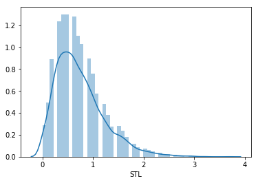

```python
sns.distplot(sns_df['STL'])
```

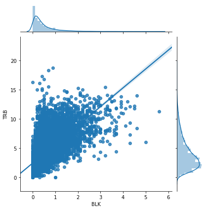

```python
sns.jointplot(x='BLK', y='TRB', data=sns_df, kind='reg')
```

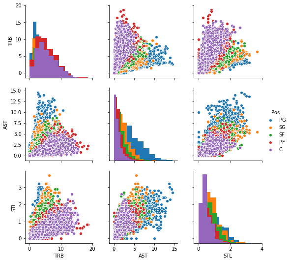

```python
test_df = sns_df[['Pos', 'TRB','AST','STL']]
sns.pairplot(test_df, hue='Pos', diag_kind='hist', hue_order=['PG', 'SG', 'SF', 'PF', 'C'])
```

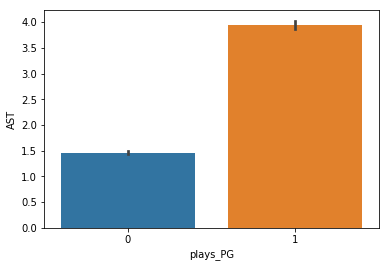

```python
sns.barplot(x='plays_PG', y='AST', data=sns_df)
```

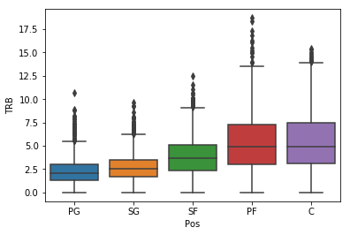

```python
sns.boxplot(x='Pos', y='TRB', data=sns_df, order=['PG', 'SG', 'SF', 'PF', 'C'])
```

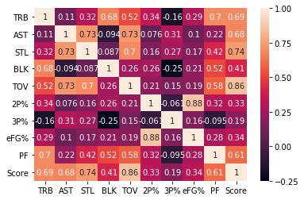

```python
sns.heatmap(sns_df[['TRB','AST','STL','BLK','TOV', '2P%', '3P%', 'eFG%', 'PF', 'Score']].corr(), annot=True)
```

## Plotly for Python and Cufflinks

https://plot.ly/python/

Plotly's Python graphing library makes interactive, publication-quality graphs online.

```
(venv) [nmichas@my-pc]$ pip install plotly
(venv) [nmichas@my-pc]$ pip install cufflinks
```

```python
import pandas as pd
import numpy as np
import cufflinks as cf
from plotly.offline import download_plotlyjs, init_notebook_mode, plot, iplot
init_notebook_mode(connected=True)
cf.go_offline()
%matplotlib inline
```

```python
plotly_df = get_clear_seasons_data()
```

```python
plotly_df.iplot(
    kind='scatter', x='Age', y='Score', text='ShortName', mode='markers',
    layout={'autosize':False, 'width':800, 'height':600, 'hovermode': 'closest'})

# plotly and cufflinks does not work well with jupyter's slides
```

[interactive chart not shown]

## Step 4.

### Predict Next Season.

We will use some Python Machine Learning Libraries in order to find out how every player will perform the next season

## Scikit-learn

http://scikit-learn.org/

Scikit-learn is a free software machine learning library for the Python programming language. It features various classification, regression and clustering algorithms including support vector machines, random forests, gradient boosting, k-means and DBSCAN, and is designed to interoperate with the Python numerical and scientific libraries NumPy and SciPy.

```
(venv) [nmichas@my-pc]$ pip install scikit-learn
```

# Regression analysis

From Wikipedia, the free encyclopedia

In statistical modeling, regression analysis is a set of statistical processes for estimating the relationships among variables. It includes many techniques for modeling and analyzing several variables, when the focus is on the relationship between a dependent variable and one or more independent variables (or 'predictors'). More specifically, regression analysis helps one understand how the typical value of the dependent variable (or 'criterion variable') changes when any one of the independent variables is varied, while the other independent variables are held fixed.

### Predict with Linear Regression

```python
import pandas as pd
import numpy as np
import matplotlib.pyplot as plt
import seaborn as sns
%matplotlib inline
```

```python
from clear_seasons_data import get_clear_final_data
```

```python
def get_train_test_datasets(df):
    max_season = df['Season_Numeric'].max()
    df_train = df[df['Season_Numeric'] != max_season]
    df_test = df[df['Season_Numeric'] == max_season]
    X_train = df_train.drop(columns=['Next_Season_Score'])
    y_train = df_train['Next_Season_Score']
    X_test = df_test.drop(columns=['Next_Season_Score'])
    y_test = df_test['Next_Season_Score']
    return X_train, X_test, y_train, y_test
```

```python
regr_df = get_clear_final_data()
X_train, X_test, y_train, y_test = get_train_test_datasets(regr_df)
```

```python
X_train.head(5)
```

|  | Height | Weight | Age | G | GS | MP | FG | FGA | FG% | 3P | ... | BLK | TOV | PF | PTS | plays_PG | plays_SG | plays_SF | plays_PF | plays_C | Season_Numeric |
| --- | --- | --- | --- | --- | --- | --- | --- | --- | --- | --- | --- | --- | --- | --- | --- | --- | --- | --- | --- | --- | --- |
| 0 | 208.3 | 240 | 22.0 | 43.0 | 0.0 | 6.7 | 1.3 | 2.7 | 0.474 | 0.0 | ... | 0.3 | 0.5 | 0.9 | 3.1 | 0 | 0 | 0 | 1 | 0 | 41 |
| 1 | 208.3 | 240 | 23.0 | 71.0 | 1.0 | 13.2 | 2.5 | 5.1 | 0.493 | 0.0 | ... | 0.2 | 0.9 | 1.9 | 6.1 | 0 | 0 | 0 | 1 | 0 | 42 |
| 2 | 208.3 | 240 | 24.0 | 75.0 | 52.0 | 17.5 | 3.3 | 6.3 | 0.518 | 0.0 | ... | 0.3 | 1.3 | 2.5 | 7.7 | 0 | 0 | 0 | 1 | 0 | 43 |
| 3 | 208.3 | 240 | 25.0 | 13.0 | 0.0 | 12.2 | 1.8 | 4.2 | 0.436 | 0.0 | ... | 0.2 | 1.3 | 1.5 | 4.9 | 0 | 0 | 0 | 1 | 0 | 44 |
| 4 | 218.4 | 225 | 34.0 | 76.0 | 76.0 | 35.2 | 9.9 | 17.1 | 0.579 | 0.0 | ... | 2.7 | 3.0 | 2.9 | 23.9 | 0 | 0 | 0 | 0 | 1 | 32 |

5 rows × 34 columns

```python
y_train.head(5)
```

```
0    12.325
1    14.950
2     8.350
3     8.500
4    44.350
Name: Next_Season_Score, dtype: float64
```

```python
from sklearn.linear_model import LinearRegression
lm = LinearRegression()
lm.fit(X_train,y_train)
```

```
LinearRegression(copy_X=True, fit_intercept=True, n_jobs=1, normalize=False)
```

```python
lm.intercept_
```

```
19.390105326328374
```

```python
lm.coef_
```

```
array([-1.62823036e-02,  4.15601307e-03, -4.21215753e-01,  2.53078338e-02,
       -9.78700150e-03, -2.22532612e-01,  6.52200483e-01, -2.20696560e-01,
       -5.15913294e+00,  3.70380493e+00, -9.80280912e-01, -1.36486384e-01,
        2.23047050e+00, -7.86904051e-01,  5.18996156e+00, -7.18298303e+00,
        1.43034951e+00, -6.28300398e-01, -5.12766833e-01,  2.47388821e+00,
        2.50854260e+00, -1.25279451e+00,  1.89030934e+00,  3.21056009e+00,
        2.68854892e+00, -1.17614684e+00, -7.65141144e-01,  7.58430663e-01,
        8.48358157e-01,  8.18898330e-01,  7.68414798e-01,  4.24741807e-01,
        9.26033901e-01, -1.82307125e-03])
```

```python
coeff_df = pd.DataFrame(lm.coef_,X_train.columns,columns=['Coefficient'])
coeff_df.transpose()
```

|  | Height | Weight | Age | G | GS | MP | FG | FGA | FG% | 3P | ... | BLK | TOV | PF | PTS | plays_PG | plays_SG | plays_SF | plays_PF | plays_C | Season_Numeric |
| --- | --- | --- | --- | --- | --- | --- | --- | --- | --- | --- | --- | --- | --- | --- | --- | --- | --- | --- | --- | --- | --- |
| Coefficient | -0.016282 | 0.004156 | -0.421216 | 0.025308 | -0.009787 | -0.222533 | 0.6522 | -0.220697 | -5.159133 | 3.703805 | ... | 2.688549 | -1.176147 | -0.765141 | 0.758431 | 0.848358 | 0.818898 | 0.768415 | 0.424742 | 0.926034 | -0.001823 |

1 rows × 34 columns

```python
predictions = lm.predict(X_test)
```

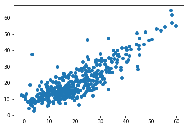

```python
plt.scatter(y_test,predictions)
```

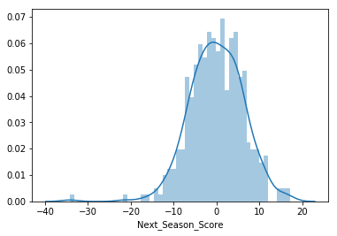

```python
sns.distplot((y_test-predictions),bins=50)
```

```python
from sklearn import metrics
print('Mean Absolute Error     :', metrics.mean_absolute_error(y_test, predictions))
print('Mean Squared Error      :', metrics.mean_squared_error(y_test, predictions))
print('Root Mean Squared Error :', np.sqrt(metrics.mean_squared_error(y_test, predictions)))
```

```
Mean Absolute Error     : 4.90991732806849
Mean Squared Error      : 39.127676770519244
Root Mean Squared Error : 6.255211968472311
```

### Compare Other Regression Methods

```python
import pandas as pd
import numpy as np
import matplotlib.pyplot as plt
import seaborn as sns
%matplotlib inline

from clear_seasons_data import get_clear_final_data
compare_df = get_clear_final_data()
X = df.drop(columns=['Next_Season_Score'])
y = df['Next_Season_Score']
```

```python
X.head()
```

|  | Height | Weight | Age | G | GS | MP | FG | FGA | FG% | 3P | ... | BLK | TOV | PF | PTS | plays_PG | plays_SG | plays_SF | plays_PF | plays_C | Season_Numeric |
| --- | --- | --- | --- | --- | --- | --- | --- | --- | --- | --- | --- | --- | --- | --- | --- | --- | --- | --- | --- | --- | --- |
| 0 | 208.3 | 240 | 22.0 | 43.0 | 0.0 | 6.7 | 1.3 | 2.7 | 0.474 | 0.0 | ... | 0.3 | 0.5 | 0.9 | 3.1 | 0 | 0 | 0 | 1 | 0 | 41 |
| 1 | 208.3 | 240 | 23.0 | 71.0 | 1.0 | 13.2 | 2.5 | 5.1 | 0.493 | 0.0 | ... | 0.2 | 0.9 | 1.9 | 6.1 | 0 | 0 | 0 | 1 | 0 | 42 |
| 2 | 208.3 | 240 | 24.0 | 75.0 | 52.0 | 17.5 | 3.3 | 6.3 | 0.518 | 0.0 | ... | 0.3 | 1.3 | 2.5 | 7.7 | 0 | 0 | 0 | 1 | 0 | 43 |
| 3 | 208.3 | 240 | 25.0 | 13.0 | 0.0 | 12.2 | 1.8 | 4.2 | 0.436 | 0.0 | ... | 0.2 | 1.3 | 1.5 | 4.9 | 0 | 0 | 0 | 1 | 0 | 44 |
| 4 | 218.4 | 225 | 34.0 | 76.0 | 76.0 | 35.2 | 9.9 | 17.1 | 0.579 | 0.0 | ... | 2.7 | 3.0 | 2.9 | 23.9 | 0 | 0 | 0 | 0 | 1 | 32 |

5 rows × 34 columns

```python
y.head()
```

```
0    12.325
1    14.950
2     8.350
3     8.500
4    44.350
Name: Next_Season_Score, dtype: float64
```

```python
from sklearn.model_selection import KFold
from sklearn.linear_model import LinearRegression, Lasso, Ridge, ElasticNet
```

```python
a = 0.9

methods = [
    ('linear regression', LinearRegression()),
    ('lasso', Lasso(fit_intercept=True, alpha=a)),
    ('ridge', Ridge(fit_intercept=True, alpha=a)),
    ('elastic-net', ElasticNet(fit_intercept=True, alpha=a))
]
```

```python
for name,met in methods:
    met.fit(X,y)
    p = met.predict(X)
    e = p-y
    total_error = np.dot(e,e)
    rmse_train = np.sqrt(total_error/len(p))

    print('Method: %s' %name)
    print('RMSE on training: %.4f' %rmse_train)
    print("\n")
```

```
Method: linear regression
RMSE on training: 6.0929


Method: lasso
RMSE on training: 6.4137


Method: ridge
RMSE on training: 6.0930


Method: elastic-net
RMSE on training: 6.4085
```

```python
for name,met in methods:

    kf = KFold(n_splits=10)
    err = 0
    for train_index, test_index in kf.split(X):
        X_train, X_test = X.iloc[train_index], X.iloc[test_index]
        y_train, y_test = y[train_index], y[test_index]
        met.fit(X_train, y_train)
        p = met.predict(X_test)
        e = p - y_test
        err += np.dot(e,e)

    rmse_10cv = np.sqrt(err/len(X))
    print('Method: %s' %name)
    print('RMSE on 10-fold CV: %.4f' %rmse_10cv)
    print("\n")
```

```
Method: linear regression
RMSE on 10-fold CV: 6.1106


Method: lasso
RMSE on 10-fold CV: 6.4207


Method: ridge
RMSE on 10-fold CV: 6.1099


Method: elastic-net
RMSE on 10-fold CV: 6.4172
```

## Neural Networks with Keras and Tensorflow

### Keras

https://keras.io/

Keras is a high-level neural networks API, written in Python and capable of running on top of TensorFlow, CNTK, or Theano. It was developed with a focus on enabling fast experimentation. Being able to go from idea to result with the least possible delay is key to doing good research.

### Tensorflow

https://www.tensorflow.org/

TensorFlow™ is an open source software library for high performance numerical computation. Originally developed by researchers and engineers from the Google Brain team within Google’s AI organization.

```python
import numpy
import pandas
from keras.models import Sequential
from keras.layers import Dense
from keras.wrappers.scikit_learn import KerasRegressor
from sklearn.model_selection import cross_val_score
from sklearn.model_selection import KFold
from sklearn.preprocessing import StandardScaler
from sklearn.pipeline import Pipeline
```

```python
from clear_seasons_data import get_clear_final_data, get_train_test_datasets
keras_df = get_clear_final_data()
X_train, X_test, y_train, y_test = get_train_test_datasets(keras_df)
```

```python
# define base model
def baseline_model():
    # create model
    model = Sequential()
    model.add(Dense(30, input_dim=34, kernel_initializer='normal', activation='relu'))
    model.add(Dense(10, kernel_initializer='normal', activation='relu'))
    model.add(Dense(1, kernel_initializer='normal'))
    # Compile model
    model.compile(loss='mean_squared_error', optimizer='adam')
    return model
```

```python
estimator = KerasRegressor(build_fn=baseline_model, epochs=200, batch_size=256, verbose=2)
```

```python
estimator.fit(X_train, y_train)
```

```
 - 0s - loss: 312.0942
 - 0s - loss: 113.4585
 - 0s - loss: 95.6988
 - 0s - loss: 78.9473
 - 0s - loss: 64.9561
 - 0s - loss: 57.8780
 - 0s - loss: 55.0911
 - 0s - loss: 52.4628
 - 0s - loss: 50.0172
 - 0s - loss: 47.7670
 - 0s - loss: 46.0220
 - 0s - loss: 44.8077
 - 0s - loss: 43.9665
 - 0s - loss: 43.3903
 - 0s - loss: 43.0573
 - 0s - loss: 42.7332
 - 0s - loss: 42.3453
 - 0s - loss: 41.7828
 - 0s - loss: 41.5904
 - 0s - loss: 41.1256
 - 0s - loss: 40.9339
 - 0s - loss: 40.7054
 - 0s - loss: 40.5554
 - 0s - loss: 40.4031
 - 0s - loss: 40.1954
 - 0s - loss: 39.7866
 - 0s - loss: 39.7985
 - 0s - loss: 39.4875
 - 0s - loss: 39.3296
 - 0s - loss: 39.1642
 - 0s - loss: 39.2235
 - 0s - loss: 39.0150
 - 0s - loss: 39.0894
 - 0s - loss: 38.9542
 - 0s - loss: 38.8264
 - 0s - loss: 38.6044
 - 0s - loss: 38.5970
 - 0s - loss: 38.5702
 - 0s - loss: 38.5619
 - 0s - loss: 38.5293
```

[output cut: 145 more lines]

```
 - 0s - loss: 36.5631
 - 0s - loss: 36.6200
 - 0s - loss: 36.5714
 - 0s - loss: 36.6599
 - 0s - loss: 36.6022
 - 0s - loss: 36.5064
 - 0s - loss: 37.0760
 - 0s - loss: 36.7490
 - 0s - loss: 36.7518
 - 0s - loss: 36.6716
 - 0s - loss: 36.5557
 - 0s - loss: 36.5902
 - 0s - loss: 36.5074
 - 0s - loss: 36.5968
 - 0s - loss: 36.7053
```

```
<keras.callbacks.History at 0x7fd5e057d0f0>
```

```python
predictions = estimator.predict(X_test)
```

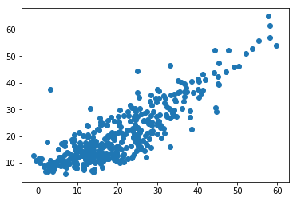

```python
import matplotlib.pyplot as plt
%matplotlib inline
plt.scatter(y_test,predictions)
```

```python
from sklearn import metrics
import numpy as np
print('MAE:', metrics.mean_absolute_error(y_test, predictions))
print('MSE:', metrics.mean_squared_error(y_test, predictions))
print('RMSE:', np.sqrt(metrics.mean_squared_error(y_test, predictions)))
```

```
MAE: 4.914197292619822
MSE: 38.829376526137125
RMSE: 6.23132221331373
```

## Step 5.

Use the predictions

```python
from clear_seasons_data import get_clear_final_data, get_train_test_datasets

final_df = get_clear_final_data(with_labels=True)
X_train, X_test, y_train, y_test = get_train_test_datasets(final_df)
labels_train = X_train[['Player']]
labels_test = X_test[['Player']]
X_train.drop(columns=['Player'], inplace=True)
X_test.drop(columns=['Player'], inplace=True)
```

```python
from sklearn.linear_model import LinearRegression
lm = LinearRegression()
lm.fit(X_train, y_train)
predictions = lm.predict(X_test)
```

```python
labels_test['Prediction'] = predictions
```

```python
prediction_df_sorted = labels_test.sort_values(by='Prediction', ascending=False)
```

```python
prediction_df_sorted[:5]
```

|  | Player | Prediction |
| --- | --- | --- |
| 11892 | Russell Westbrook | 64.568737 |
| 4664 | James Harden | 61.799162 |
| 2719 | Anthony Davis | 56.979021 |
| 5627 | LeBron James | 54.898267 |
| 369 | Giannis Antetokounmpo | 54.394127 |

```python
prediction_df_sorted[5:10]
```

|  | Player | Prediction |
| --- | --- | --- |
| 3285 | Kevin Durant | 53.026744 |
| 2441 | DeMarcus Cousins | 52.271180 |
| 11256 | Karl-Anthony Towns | 51.269578 |
| 11706 | John Wall | 50.722309 |
| 1737 | Jimmy Butler | 47.564992 |

## Next Steps

### Potential Improvements

- Use college stats for rookies or international stats for foreigners
- Use more than one season as an input (fewer data)
- Use more advanced stats (Stats per posession, Team averages, ...)

# Q & A

[figure not shown]

## Nikolaos Michas

### PyCon Balkan 2018